# Red Wine Quality Data Analysis by Paul Hsiao

## Plot Three - pH vs median_alcohol with smoother

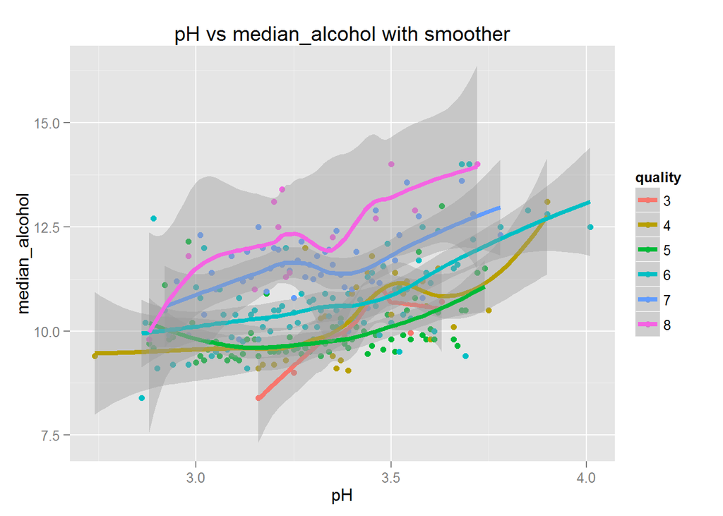

The correlation between pH and median_alcohol per quality -

| quality | Correlation between pH and median_alcohol |
| --- | --- |
| 3 | 0.8501442 |
| 4 | 0.5897489 |
| 5 | 0.3716999 |
| 6 | 0.5972137 |
| 7 | 0.4959361 |
| 8 | 0.7654621 |

## Description

In the multivariate analysis section, this plot is the highlight plot. So I put it in the final section.

It shows the pH vs median_alcohol trend per quality. There are three conclusions drawn from the plot:

# Reflection

It is a interesting subject to explore using the Data Analysis we learnt in this course. Without knowing much about the relationship between features, it was a bit hard to pick the features of interest in the begining. However, once I went through the Univariate, bivariate and multivariate ploting involving different feature combinations, the picture is getting clear. Even though there is no definite conclusion from the analysis, a few key observations did provide us a good picture for the relationship of quality and interested features. There are still a lot of plotting technics we have not applied during the course yet. Even though the dataset provides only limited features in red wine, I believe with further exploring using more plotting technics, we can be more certain about the relationship between quality and features.